# A02 Answers

Olivia Martin

2022-09-20

**Instructions.** Change the author name on line 4 to be your name. Insert all requested answers. Upload in Moodle this file and a knitted file (html, doc, or pdf).

### Exercise 1 (44 points).

Answer from *Statistical Modeling: End-of-Chapter Exercises* by Daniel Kaplan the following. I provide enough of each problem (Prob) or reading exercise (Read) so that it should be relatively easy to type your answers in this file.

**Prob 1.02 (8 points).** The console window is a good place to experiment with the given code and finding code that will work. I have answered the first question so that you can see the recommended style of answer.

1. `> seq(5;8)` to give [1] 5 6 7 8  
   Use a comma instead of a semi-colon to separate arguments: `seq(5,8)`
2. `> cos 1.5` to calculate the cosine of 1.5 radians  
   Use parentheses: `cos(1.5)`
3. `> 3 + 5 = x` to make `x` take the value 3+5  
   Reverse the order, placing the variable first: `x = 3 + 5`
4. `> sqrt[4*98]` to find the square root of 392  
   Use parentheses instead of square brackets: `sqrt(4*98)`
5. `> 10,000 + 4,000` adding two numbers to get 14,000  
   Omit commas: `10000 + 4000`
6. `> sqrt(c(4,16,25,36))=4` intended to give `[1] FALSE TRUE FALSE FALSE`  
   Insert a second `=` to indicate equality rather than assignment: `sqrt(c(4,16,25,36)) == 4`
7. > fruit = c(apple, berry, cherry) to create a collection of names `[1] "apple" "berry" "cherry"`

Add quotes in the argument of the concatenation: `fruit = c('apple', 'berry', 'cherry')`

8. `> x = 4(3+2)` where `x` is intended to be assigned the value 20  
   Add the multiplication operator in the appropriate spot:`x = 4*(3+2)`
9. `> x/4 = 3+2` where `x` is intended to be assigned the value 20  
   You have to isolate a variable in order to assign it. Use the same method as the above answer: `x = 4*(3+2)`

**Prob 2.09 (3 points).** I have answered the first question so that you can see the recommended style of answer.

1. What are the rows in the above data set? (B) An individual person.
2. How many variables are there? (C) Four — the reaction times at four different levels of alcohol.
3. What are the cases in the reformatted data frame? (A) Individual measurements of reaction time.
4. How many variables are there? (B) Three — the subject, the reaction time, the alcohol level.

**Prob 2.14 (5 points).** For this problem, the three options should be nominal, ordinal, and quantitative because nominal and ordinal are types of categorical variables. I have answered part (b) so that you can see the recommended style of answer.

1. Gestation *quantitative*
2. Race *nominal*
3. Marital *nominal*
4. Inc *ordinal*
5. Smoke *nominal*
6. Number *ordinal*

**Read 3.3 (2 points).** What is a residual?

It is another, more neutral term for deviation or error, referring to the difference between the observed value and the model’s predicted value for an individual case.

**Read 3.4 (3 points).** What’s the difference between “density” and “frequency” in displaying a variable with a histogram?

Density and frequency are two ways to segment the y-axis of a histogram. Frequency means that the height of each bar corresponds to the number of cases that fall into that bar’s bin. Density means that the height of each bar corresponds to the *proportion* of cases that fall into that bar’s bin. Note that a histogram displayed by density is not the same as a density plot, which is somewhat similar but does not divide cases into bins.

**Read 3.5 (2 points).** What’s a normal distribution?

The Normal distribution is a common distribution that is shaped like a bell curve. It follows the empirical rule, stating that 68%, 95%, and 99.7% of the data should fall within one, two, and three standard deviations of the mean, respectively.

**Read 3.7 (3 points).** Variables typically have units. For example, in Galton’s height data, the height variable has units of inches. Suppose you are working with a variable in units of degrees celsius. What would be the units of the standard deviation of a variable? Of the variance? Why are they different?

The standard deviation would be in units of degrees celsius, and the variance would be in degrees celsius squared, because the variance is the square of the standard deviation. When you square the value, you must also square the unit.

**Prob 3.01 (6 points).** Based on a table of percentiles.

**Prob 3.18 (10 points).** Based on two density plots.

1. Part 1 Mean. 20
2. Part 1 Std. Dev. 5
3. Part 1 95% coverage interval Lower end: 10 (mean minus two standard deviations, per the empirical rule)
4. Part 1 95% coverage interval Upper end: 30
5. Part 1 Variance. 25
6. Part 2 Mean. 180 (150 is too low and 250 is too high)
7. Part 2 Std. Dev. 30 (looks right, and is the only option for which the square appears on the list of potential variances)
8. Part 2 95% coverage interval Lower end: 135 (180-2*30 is 120, but the hump on the left could account for this discrepancy)
9. Part 2 95% coverage interval Upper end : 230 (180+2*30 is 240, but again, the hump on the left makes this plausible)
10. Part 2 Variance. 900

**Read 4.1 (2 points).** Which is largest: variance of residuals, variance of the model values, or the variance of the actual values?

The variance of the actual values.

### Exercise 2 (50 points)

Use the `chickwts` data set to do the following. Your answer for each part should include one or more sentences and a code chunk.

1. Obtain the data in the first row of the data set state the real-world meaning of the data.

```r
chickwts[1,]
```

```
##   weight      feed
## 1    179 horsebean
```

This row means that the observed chick weighed 179 grams after six weeks of receiving the “horsebean” feed supplement.

2. Obtain and state the mean and standard deviation weight of all chickens in the sample. Be sure to state units.

```r
mean(chickwts$weight)
```

```
## [1] 261.3099
```

```r
sd(chickwts$weight)
```

```
## [1] 78.0737
```

The mean is 261.31 grams, and the standard deviation is 78.07 grams.

3. Obtain a histogram for the weights of all chickens that strongly suggests a bimodal distribution by choosing an appropriate number of bins. Be sure to include appropriate labels. State why the distribution of weights need not be unimodal.  
   Seven bins is the default, and suggests a bimodal distribution; however, the next step up is 17 bins (for some reason?), which shows a distinctly trimodal distribution. The bimodal histogram can be obtained with the below code. The distribution need not be unimodal because there may be sex differences between the chicks (i.e., one mode for male chicks and one mode for female chicks), or the multiple modes could suggest a significant difference in weight as predicted by type of feed.

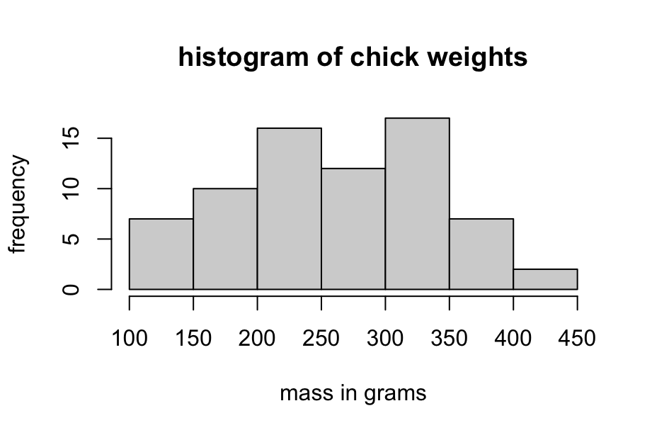

```r
hist(chickwts$weight, main = 'histogram of chick weights', xlab = 'mass in grams', ylab = 'frequency')
```

4. Obtain the count, mean weight, and standard deviation weight of the chickens grouped by the feed type. Based on these statistics, state which feed types led to the largest typical weight, the smallest typical weight, the largest spread in weights, and the smallest spread in weights.  
   I know there’s a better way to do this, but I’m too busy to figure it out. I did this by getting the counts and then running through the second set of code with each type of feed.

```r
chickwts %>% count(feed)
```

```
##        feed  n
## 1    casein 12
## 2 horsebean 10
## 3   linseed 12
## 4  meatmeal 11
## 5   soybean 14
## 6 sunflower 12
```

```r
subset(chickwts, feed == 'casein') %>% summarise('mean' = mean(weight), 'sd' = sd(weight))
```

```
##       mean       sd
## 1 323.5833 64.43384
```

According to this data, sunflower feed leads to the largest typical mass of 328.92 grams, and meatmeal leads to the largest spread in weights with a standard deviation of 64.90. Horsebean leads to the smallest typical mass of 160.2 grams, as well as the smallest spread of 38.63 grams.

5. Obtain a boxplot for the weights of chickens grouped by the type of feed. Be sure to include appropriate labels. Based on the visible medians and interquartile ranges, state which feed types led to the largest typical weight, the smallest typical weight, the largest spread in weights, and the smallest spread in weights.

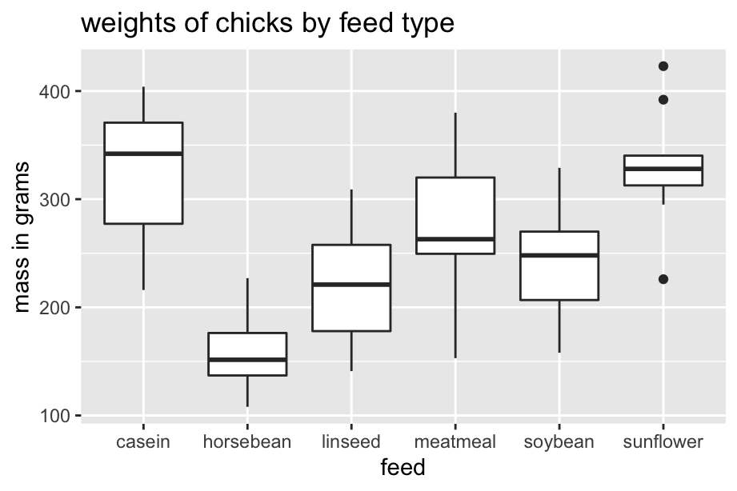

```r
ggplot(data = chickwts) +
  geom_boxplot(mapping = aes(x = feed, y = weight)) +
  labs(title = 'weights of chicks by feed type') +
  ylab('mass in grams')
```

### Exercise 3 (40 points)

Use the `infert` data set to do the following (ignoring the last two variables). Your answer for each part should include one or more sentences, and your answer for each part (except part a) should include a code chunk. Your answer for each part should include one or more sentences and a code chunk (except for part b).

1. Obtain the data in the first row of the data set state the real-world meaning of the data.  
   This was a fun battle to try to find out what they meant by parity, but eventually I did figure it out. Each case represents a person who had a spontaneous or induced abortion at some point in their life. The case in the first row has the following characteristics:  
   subject had 0-5 years of education  
   subject is 26 years old  
   subject gave birth to six infants (either alive or stillborn; birth occurred after at least 24 weeks of gestation)  
   subject had one induced abortion  
   subject is in the “treatment group” (a slight misnomer, as this is a retroactive study; the “treatment” refers to having had an abortion)  
   subject had two or more spontaneous abortions
2. State the type (categorical or quantitative) each of the first six variables are as coded in the data set.  
   education: categorical  
   age: quantitative  
   parity: quantitative  
   induced: categorical (technically, because 2 represents two or more)  
   case status: categorical  
   spontaneous: categorical (similar to induced)
3. Obtain a bar chart for the frequency for each value of a categorical variable with more than two values. State the frequency of the value with maximum frequency.

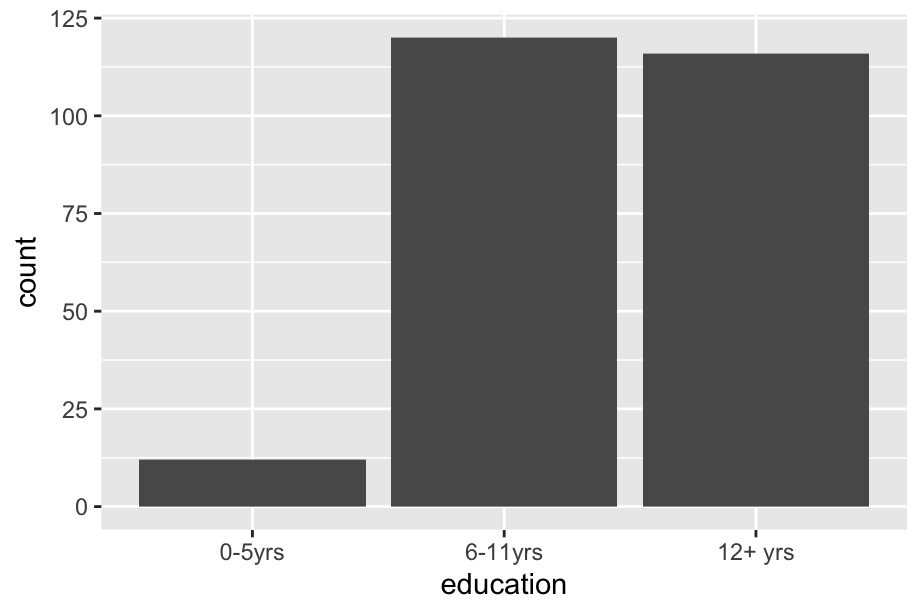

```r
ggplot(data = infert, mapping = aes(x = education)) + geom_bar()
```

6-11 yrs: n = 120

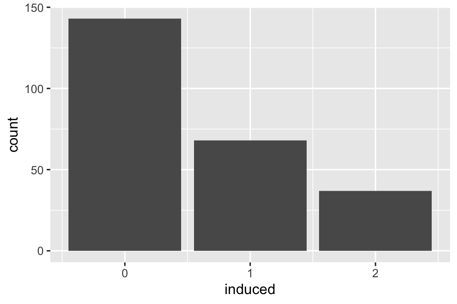

```r
ggplot(data = infert, mapping = aes(x = induced)) + geom_bar()
```

0 (no induced abortions): n = 143

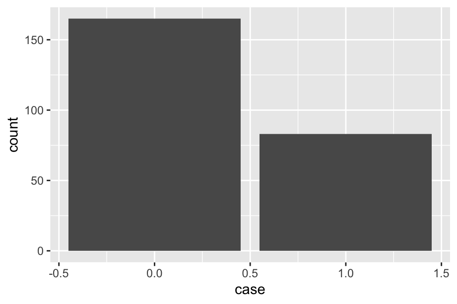

```r
ggplot(data = infert, mapping = aes(x = case)) + geom_bar()
```

0 (control): 165

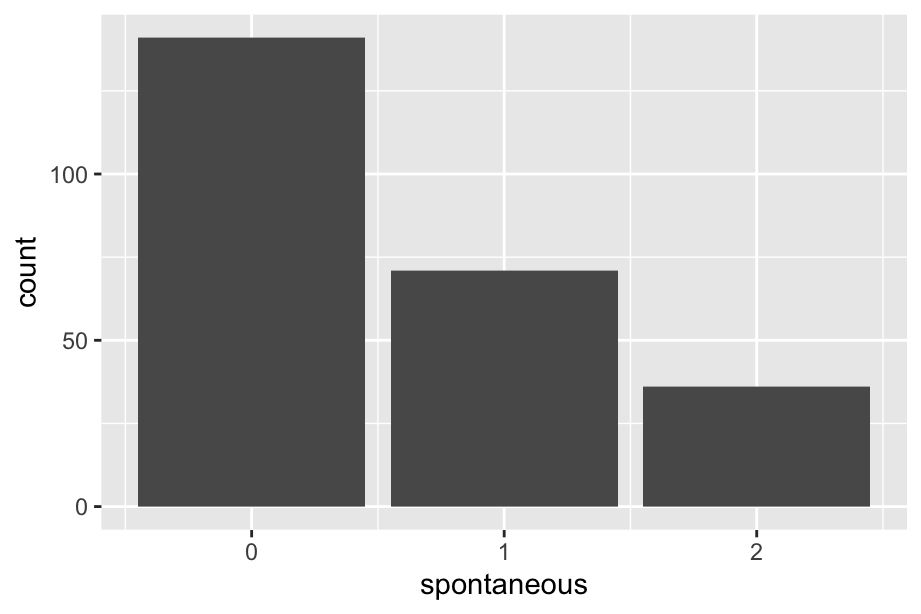

```r
ggplot(data = infert, mapping = aes(x = spontaneous)) + geom_bar()
```

0 (no spontaneous abortions): 141

4. Obtain a density plot of a quantitative variable grouped by some categorical variable. State the relationship(s) you observe between the two variables.  
   I’m partial to customizing the colors of my plots, so I went with sort of 80s electric today:

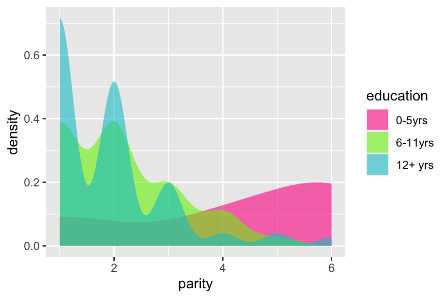

```r
ggplot(infert, aes(x = parity, fill = education)) +
  geom_density(alpha = 0.6, linetype = 'blank') +
  scale_fill_manual(values = c('deeppink', 'chartreuse2', 'turquoise3'))
```

Parity is a quantitative variable, but the density plot out of context would suggest a very odd modality. In context, we can observe that generally, subjects with more years of education gave birth fewer times. I wouldn’t be surprised if education was a useful factor in predicting parity, but it’s not going to explain a lot by itself. In addition, age by definition affects both education and parity— a 30-year-old would have had ten more years available for schooling and/or giving birth.